# Artificial Intelligence and Machine Learning

## Attention Mechanism and Transformers

[figure not shown]

# News Article Categorization

## **Problem Statement**

### Business Context

In the dynamic landscape of the media and news industry, the ability to swiftly categorize and curate content has become a strategic imperative. The vast volume of information demands efficient systems to organize and present content to the audience.

The media industry, being the pulse of information dissemination, grapples with the continuous influx of news articles spanning diverse topics. Ensuring that the right articles reach the right audience promptly is not just a logistical necessity but a critical component in retaining and engaging audiences in an age of information overload.

Common Industry Challenges: Amidst the ceaseless flow of news, organizations encounter challenges such as:

- Information Overload: The sheer volume of news articles makes manual categorization impractical.
- Timeliness: Delays in categorizing news articles can result in outdated or misplaced content.

### Problem Definition

E-news Express, a news aggregation startup, faces the challenge of categorizing the news articles collected. With news articles covering sports, entertainment, politics, and more, the need for an advanced and automated system to categorize them has become increasingly evident. The manual efforts required for categorizing such a diverse range of news articles are substantial, and human errors in the categorization of news articles can lead to reputational damage for the startup. There is also the factor of delays and potential inaccuracies. To streamline and optimize this process, the organization recognizes the imperative of adopting cutting-edge technologies, particularly machine learning, to automate and enhance the categorization of content.

The task is to analyze the text in news articles and build an unsupervised learning model for categorizing them. The categorization done by the model can then be validated against human-defined labels to check the overall accuracy of the AI system. The goal is to optimize the categorization process, ensuring timely and personalized delivery.

### Data Dictionary

- **Text**: The main body of the news article

## **Installing and importing the necessary libraries**

**Note:** We strongly advise running this notebook connected to a T4 GPU Runtime for optimal performance.

```python
# Installing the libraries with the specified versions
!pip install pandas==2.2.2 numpy==2.0.2 matplotlib==3.10.0 seaborn==0.13.2 scipy==1.15.3 scikit-learn==1.6.1 torch==2.6.0 sentence-transformers==4.1.0 -q
```

[output not shown]

**Note**:

- After running the above cell, kindly restart the runtime (for Google Colab) or notebook kernel (for Jupyter Notebook), and run all cells sequentially from the next cell.
- On executing the above line of code, you might see a warning regarding package dependencies. This error message can be ignored as the above code ensures that all necessary libraries and their dependencies are maintained to successfully execute the code in *this notebook*.

```python
# to read and manipulate the data
import pandas as pd
import numpy as np
pd.set_option('max_colwidth', None)    # setting column to the maximum column width as per the data

# to visualise data
import matplotlib.pyplot as plt
import seaborn as sns

# to compute distances
from scipy.spatial.distance import cdist, pdist
from sklearn.metrics.pairwise import cosine_similarity
from scipy.spatial import distance
from sklearn.metrics import silhouette_score

# importing the PyTorch Deep Learning library
import torch

# to import the model
from sentence_transformers import SentenceTransformer

# to cluster the data
from sklearn.cluster import KMeans

# to compute metrics
from sklearn.metrics import classification_report

# to avoid displaying unnecessary warnings
import warnings
warnings.filterwarnings("ignore")
```

## **Loading the dataset**

```python
# uncomment and run the below code snippets if the dataset is present in the Google Drive
# from google.colab import drive
# drive.mount('/content/drive')
```

```python
reviews = pd.read_csv("news_articles.csv")
```

```python
# creating a copy of the dataset
data = reviews.copy()
```

## **Data Overview**

### Checking the first five rows of the data

```python
# Print first 5 rows of data
data.head()
```

|  | Text |
| --- | --- |
| 0 | Budget to set scene for election\n \n Gordon Brown will seek to put the economy at the centre of Labour's bid for a third term in power when he delivers his ninth Budget at 1230 GMT. He is expected to… |
| 1 | Army chiefs in regiments decision\n \n Military chiefs are expected to meet to make a final decision on the future of Scotland's Army regiments.\n \n A committee of the Army Board, which is made up of… |
| 2 | Howard denies split over ID cards\n \n Michael Howard has denied his shadow cabinet was split over its decision to back controversial Labour plans to introduce ID cards.\n \n The Tory leader said his … |
| 3 | Observers to monitor UK election\n \n Ministers will invite international observers to check the forthcoming UK general election is fairly run.\n \n The move comes amid claims the poll could be marred… |
| 4 | Kilroy names election seat target\n \n Ex-chat show host Robert Kilroy-Silk is to contest the Derbyshire seat of Erewash at the next general election.\n \n Labour's Elizabeth Blackman won the seat in … |

```python
# checking a news article
data.loc[3, 'Text']
```

```
'Observers to monitor UK election\n \n Ministers will invite international observers to check the forthcoming UK general election is fairly run.\n \n The move comes amid claims the poll could be marred by electoral fraud. A report by two MPs committees called on Thursday for urgent changes to the el…
```

### Checking the last five rows of the data

```python
# Print last 5 rows of data
data.tail()
```

|  | Text |
| --- | --- |
| 2220 | India opens skies to competition\n \n India will allow domestic commercial airlines to fly long haul international routes, a move it hopes will stoke competition and drive down prices.\n \n However, o… |
| 2221 | Yukos bankruptcy 'not US matter'\n \n Russian authorities do not have to abide by any US court decisions taken with regard to troubled oil giant Yukos, a Houston court has been told.\n \n Legal expert… |
| 2222 | Survey confirms property slowdown\n \n Government figures have confirmed a widely reported slowdown of the UK's housing market in late 2004.\n \n House prices were 11.8% higher on the year in the last… |
| 2223 | High fuel prices hit BA's profits\n \n British Airways has blamed high fuel prices for a 40% drop in profits.\n \n Reporting its results for the three months to 31 December 2004, the airline made a pr… |
| 2224 | US trade gap hits record in 2004\n \n The gap between US exports and imports hit an all-time high of $671.7bn (Â£484bn) in 2004, latest figures show.\n \n The Commerce Department said the trade defici… |

### Checking the shape of the dataset

```python
# print shape of data
data.shape
```

```
(2225, 1)
```

- The data comprises of ~2.2k news articles

### Checking for missing values

```python
# Check for missing values
data.isnull().sum()
```

|  | 0 |
| --- | --- |
| Text | 0 |

**dtype:** int64

- There are no mising values in the data

### Checking for duplicate values

```python
# Check for duplicate values
data.duplicated().sum()
```

```
np.int64(98)
```

- We'll drop the duplicate values in the data.

```python
data = data.drop_duplicates()

# resetting the dataframe index
data.reset_index(drop=True, inplace=True)
```

```python
data.duplicated().sum()
```

```
np.int64(0)
```

- There are no duplicate values in the data now.

## **Model Building**

### **Defining the model**

We'll be using the **all-MiniLM-L6-v2** model here.

💡 The **all-MiniLM-L6-v2** model is an all-round (**all**) model trained on a large and diverse dataset of over 1 billion training samples and generates state-of-the-art sentence embeddings of 384 dimensions.

📊 It is a language model (**LM**) that has 6 transformer encoder layers (**L6**) and is a smaller model (**Mini**) trained to mimic the performance of a larger model (BERT).

🛠️ Potential use-cases include text classification, sentiment analysis, and semantic search.

```python
#Defining the model
model = SentenceTransformer('sentence-transformers/all-MiniLM-L6-v2')
```

### **Encoding the dataset**

```python
# setting the device to GPU if available, else CPU
device = torch.device("cuda" if torch.cuda.is_available() else "cpu")
```

```python
# encoding the dataset
embedding_matrix = model.encode(data['Text'], show_progress_bar=True, device=device)
```

```python
# printing the shape of the embedding matrix
embedding_matrix.shape
```

```
(2127, 384)
```

- Each news article has been converted to a 384-dimensional vector

```python
# printing the embedding vector of the first review in the dataset
embedding_matrix[0]
```

[output not shown]

[output cut: 42 more lines]

[output not shown]

**Note**: We have not trained or fine-tuned the model. We have used the pre-trained model to encode the dataset.

## **Semantic Search**

**Now, let's search for similar reviews in our dataset.**

```python
# defining a function to find the top k similar sentences for a given query
def top_k_similar_sentences(embedding_matrix, query_text, k):
    # encoding the query text
    query_embedding = model.encode(query_text)

    # calculating the cosine similarity between the query vector and all other encoded vectors of our dataset
    score_vector = [cosine_similarity(x.reshape(1,-1),query_embedding.reshape(1,-1))[0][0] for x in embedding_matrix]

    # sorting the scores in descending order and choosing the first k
    top_k_indices = np.argsort(score_vector)[::-1][:k]

    # returning the corresponding reviews
    return data.loc[list(top_k_indices), 'Text']
```

```python
# defining the query text
query_text = "Brown’s Budget focuses on stability with minor tax reliefs, as opposition warns of future tax hikes."

# displaying the top 5 similar sentences
top_k_reviews = top_k_similar_sentences(embedding_matrix, query_text, 5)

for i in top_k_reviews:
    print(i, end="\n\n")
```

```
Brown names 16 March for Budget

 Chancellor Gordon Brown will deliver his Budget to the House of Commons on 16 March, the Treasury has announced.

 The Budget, likely to be the last before the General Election, will be at about 1230 GMT on that Wednesday, just after Prime Minister's question time. The annual event is when the chancellor outlines the government's taxation and broader economic predictions. The Tories say it is likely the Budget …

 Next month's Budget will be Mr Brown's ninth since Labour came to power in 1997. If a May election is called, there could be as little as 18 days between the Budget and the announcement of a date for the election. A shortened Finance Bill would have to be rushed through Parliament with all-party su…

 The full Finance Bill, with the Budget measures in it, would then be returned to the Commons after the election, if Labour secures another term in office. Tory shadow chancellor Oliver Letwin said: "We can be sure of two things: the Budget will contain measures to attract votes, and it will not con…


Brown shrugs off economy fears

 Gordon Brown is to freeze petrol duty increases, fund a Â£1bn package to avoid big council tax rises and boost childcare and maternity leave.

 In an upbeat pre-Budget report, he slightly increased borrowing but insisted economic targets would be met. The chancellor also hailed the longest period of growth in UK "industrial history" but denied he was "gloating". But Oliver Letwin, for the Tories, attacked government red tape and debt, dubb…

 The shadow chancellor said Mr Brown's "golden rule" had "turned to dross in his hands" and said he was borrowing to spend, not invest, with predicted debt over the coming years totalling Â£170bn. Mr Letwin told MPs: "The tide is going out on the chancellor's credibility. He is spending, borrowing a…

 Vincent Cable, for the Liberal Democrats, accused Mr Brown of ducking tough choices.

 He said: "Last week the prime minister gave us the politics of fear; this week the chancellor has offered the economics of complacency. "There are serious challenges ahead from the falling dollar and from the rapid downturn in the UK housing market and rising personal debt. But they have not been c…

 Mr Brown's insistence he was not "gloating" was a pointed rebuttal of a warning from new European Commissioner Peter Mandelson. In his speech, he set out a 10-year childcare strategy for if Labour wins the next election.

 It includes a Â£285m cash injection to extend paid maternity leave from six months to nine, with parents able to transfer leave from the mother to the father. He also promised to increase free nursery education for three and four-year-olds to 15 hours from April 2007. And funds would be provided to…

 Mr Brown said he was set to meet his two fiscal rules - to borrow only to invest and keep debt "low and sustainable" - both in this economic cycle and the next. Borrowing figures for 2003/4 are Â£35bn - Â£2.5bn less than the Â£37.5bn predicted in March's budget, as already announced by the Office f…


Golden rule boost for Chancellor

 Chancellor Gordon Brown has been given a Â£2.1bn boost in his attempts to meet his golden economic rule, which allows him to borrow only for investment.

 The extra leeway came after the Office for National Statistics said it had been measuring road expenditure data wrongly over the past five years. It comes just weeks ahead of the Budget and an expected general election. Shadow chancellor Oliver Letwin said: "At best the timing of these changes is v…

 A review by the ONS found it had made a mistake by "double counting" some spending on roads since 1998/9. Correcting the error would mean reducing current expenditure and increasing net investment, thus helping Mr Brown to meet his "golden rule" of borrowing only to invest over the economic cycle. …

 The changes by the ONS increase the current budget measure for the past five years by Â£2.1bn in total. Mr Letwin said: "This is a very murky area... There will inevitably be suspicions that the figures are being fiddled." The Conservatives also said Mr Brown would still be forced to raise taxes af…

```

[output cut: 12 more lines]

```

 In a speech at Edinburgh's Napier University, he said Labour would publish over the next few months "a rich agenda for future policy in any possible third term".

 "In every area of work there is a detailed plan for the future, much clearer than those in 1997 or 2001. All of it fits together around common themes of opportunity, security and stability for all," Mr Blair said. In his pre-Budget report, Mr Brown surprised some City experts by forecasting UK grow…

 Conservative Shadow chancellor Oliver Letwin said: "I can't find a single economic forecaster from the IMF to the Institute of Fiscal Studies who believes anything other than the chancellor has got a black hole in his finances. "In order to deal with that he will have to raise taxes after the next …


Brown names 16 March for Budget

 Chancellor Gordon Brown will deliver his Budget to the House of Commons on 16 March, the Treasury has announced.

 The Budget, likely to be the last before the General Election, will be at 1230 GMT on that Wednesday, just after Prime Minister's question time. The annual event is when the chancellor outlines the government's taxation and broader economic predictions. It is likely to set out much of the tax and s…

 Next month's Budget will be Mr Brown's eighth since Labour came to power in 1997. If a May election is called, there could be as little as 18 days between the Budget and the announcement of a date for the election. A shortened Finance Bill would have to be rushed through Parliament with all-party s…
```

```python
# defining the query text
query_text = "High imports and exports"

# displaying the top 5 similar sentences
top_k_reviews = top_k_similar_sentences(embedding_matrix, query_text, 5)

for i in top_k_reviews:
    print(i, end="\n\n")
```

```
US trade gap ballooned in October

 The US trade deficit widened by more than expected in October, hitting record levels after higher oil prices raised import costs, figures have shown

 The trade shortfall was $55.5bn (Â£29bn), up 9% from September, the Commerce Department said. That pushed the 10 month deficit to $500.5bn. Imports rose by 3.4%, while exports increased by only 0.6%. A weaker dollar also increased the cost of imports, though this should help drive export demand in …

 Despite this optimism, significant concerns remain as to how the US will fund its trade and budget deficits should they continue to widen. Another problem highlighted by analysts was the growing trade gap with China, which has been accused of keeping its currency artificially weak in order to boost…


Trade gap narrows as exports rise

 The UK's trade gap narrowed in November, helped by a 7.5% rise in exports outside the European Union.

 According to the Office for National Statistics, the difference between what the UK exported and imported was Â£3.1bn ($5.8bn), down from October's Â£3.6bn. Overall UK exports - including both goods and services - rose by more than 3.2% to Â£24.8bn, although total imports rose again to a new record…

 November saw an improvement in export levels to both the European Union and the rest of the world, the Office for National Statistics (ONS) said. EU exports rose 2%, fuelled by an increase in sales of chemicals. Non-EU exports shot up 7.5%, with growth seen across a range of manufacturing sectors i…

 The UK's deficit with the EU fell to Â£1.9bn from Â£2.1bn, while its non-EU shortfall dropped to Â£2.7bn from Â£2.9bn in October.

 The country's surplus on trade-in-services remained steady at Â£1.5bn for the fifth month in a row. Paul Dales, UK economist for Capital Economics, said the figures represented an improvement on recent months. However, he stressed that the long-term prognosis for exports was still uncertain. "The f…


US trade gap hits record in 2004

 The gap between US exports and imports hit an all-time high of $671.7bn (Â£484bn) in 2004, latest figures show.

 The Commerce Department said the trade deficit for all of last year was 24.4% above the previous record - 2003's imbalance of $496.5bn. The deficit with China, up 30.5% at $162bn, was the largest ever recorded with a single country. However, on a monthly basis the US trade gap narrowed by 4.9% in D…

 Democrats claim the administration has not done enough to clamp down on unfair foreign trade practices. For example, they believe China's currency policy - which US manufacturers claim has undervalued the yuan by as much as 40% - has given China's rapidly expanding economy an unfair advantage again…

 Meanwhile, the Bush administration argues that the US deficit reflects the fact the America is growing at faster rate than the rest of the world, spurring on more demand for imported goods. Some economists say this may allow an upward revision of US economic growth in the fourth quarter. But others…


FAO warns on impact of subsidies

 Billions of farmers' livelihoods are at risk from falling commodity prices and protectionism, the UN's Food & Agriculture Organisation has warned.

 Trade barriers and subsidies "severely" distort the market, the FAO report on the "State of Agricultural Commodity Markets 2004" said. As a result, the 2.5 billion people in the developing world who rely on farming face food insecurity. The most endangered are those who live in the least-developed …

 The FAO has urged the World Trade Organisation to swiftly conclude negotiations to liberalise trade, easing developing countries' access to the world market. It also criticised the high tariffs imposed by both developed and developing nations. It recommends that developing countries reduce their ow…

 According to the organisation, subsidies and high tariffs have a strong impact on the trade of products such as cotton and rice. Global exports of these products are mainly in the hands of the European Union and the US, who - thanks to subsidies - sell them at very low prices. In fact, almost 30 we…


Chinese exports rise 25% in 2004

 Exports from China leapt during 2004 over the previous year as the country continued to show breakneck growth.

 The spurt put China's trade surplus - a sore point with some of its trading partners - at a six-year high. It may also increase pressure on China to relax the peg joining its currency, the yuan, with the weakening dollar. The figures released by the Ministry of Commerce come as China's tax chief co…

 According to the Ministry of Commerce, China's exports totalled $63.8bn in December, taking the annual total up 35.4% to $593.4bn. With imports rising a similar amount, the deficit rose to $43.4bn. The increased tax take comes despite healthy tax rebates for many exporters totalling 420bn yuan in 2…
```

## **Categorization**

**We'll use K-Means Clustering to categorize the data.**

```python
meanDistortions = []
clusters = range(2, 11)

for k in clusters:
    clusterer = KMeans(n_clusters=k, random_state=1)
    clusterer.fit(embedding_matrix)

    prediction = clusterer.predict(embedding_matrix)

    distortion = clusterer.inertia_
    meanDistortions.append(distortion)

    print("Number of Clusters:", k, "\tAverage Distortion:", distortion)
```

```
Number of Clusters: 2 	Average Distortion: 1795.309326171875
Number of Clusters: 3 	Average Distortion: 1737.2989501953125
Number of Clusters: 4 	Average Distortion: 1666.6715087890625
Number of Clusters: 5 	Average Distortion: 1621.48486328125
Number of Clusters: 6 	Average Distortion: 1591.502685546875
Number of Clusters: 7 	Average Distortion: 1577.10546875
Number of Clusters: 8 	Average Distortion: 1571.6837158203125
Number of Clusters: 9 	Average Distortion: 1559.942138671875
Number of Clusters: 10 	Average Distortion: 1534.3988037109375
```

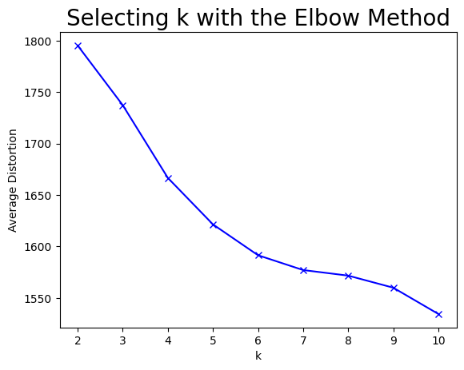

```python
plt.plot(clusters, meanDistortions, "bx-")
plt.xlabel("k")
plt.ylabel("Average Distortion")
plt.title("Selecting k with the Elbow Method", fontsize=20)
plt.show()
```

- The appropriate value of k from the Elbow curve seems to 5.

**Let's check the silhouette scores.**

```python
sil_score = []
cluster_list = range(2, 10)

for n_clusters in cluster_list:
    clusterer = KMeans(n_clusters=n_clusters, random_state=1)

    preds = clusterer.fit_predict((embedding_matrix))

    score = silhouette_score(embedding_matrix, preds)
    sil_score.append(score)

    print("For n_clusters = {}, the silhouette score is {})".format(n_clusters, score))
```

```
For n_clusters = 2, the silhouette score is 0.04681149870157242)
For n_clusters = 3, the silhouette score is 0.04964282363653183)
For n_clusters = 4, the silhouette score is 0.060650650411844254)
For n_clusters = 5, the silhouette score is 0.06735046207904816)
For n_clusters = 6, the silhouette score is 0.06096599996089935)
For n_clusters = 7, the silhouette score is 0.05802199989557266)
For n_clusters = 8, the silhouette score is 0.053445685654878616)
For n_clusters = 9, the silhouette score is 0.05067499727010727)
```

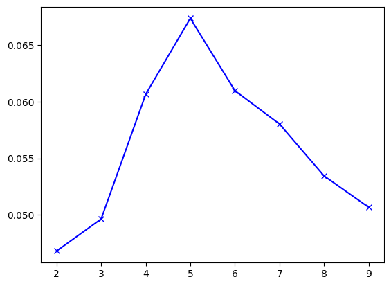

```python
plt.plot(cluster_list, sil_score, "bx-")
plt.show()
```

- The silhouette coefficient for 5 clusters is the highest.
- So, we will proceed with 5 clusters.

```python
# defining the number of clusters/categories
n_categories = 5

# fitting the model
kmeans = KMeans(n_clusters=n_categories, random_state=1).fit(embedding_matrix)
```

```python
# checking the cluster centers
centers = kmeans.cluster_centers_
centers
```

```
array([[-0.01785408,  0.00624578, -0.00339485, ..., -0.06009006,
        -0.03252156,  0.01114385],
       [ 0.00549149, -0.02162502,  0.01707269, ..., -0.03975476,
        -0.01703277,  0.01147504],
       [-0.01044314, -0.04308654, -0.0162626 , ..., -0.06730249,
        -0.00805317,  0.00465476],
       [-0.01394477, -0.03756044,  0.00739344, ..., -0.10312268,
        -0.01400102,  0.03134283],
       [-0.02824865, -0.03118994,  0.00693419, ..., -0.05258857,
         0.00538872,  0.03337952]], dtype=float32)
```

```python
# creating a copy of the data
clustered_data = data.copy()

# assigning the cluster/category labels
clustered_data['Category'] = kmeans.labels_

clustered_data.head()
```

|  | Text | Category |
| --- | --- | --- |
| 0 | Budget to set scene for election\n \n Gordon Brown will seek to put the economy at the centre of Labour's bid for a third term in power when he delivers his ninth Budget at 1230 GMT. He is expected to… | 1 |
| 1 | Army chiefs in regiments decision\n \n Military chiefs are expected to meet to make a final decision on the future of Scotland's Army regiments.\n \n A committee of the Army Board, which is made up of… | 1 |
| 2 | Howard denies split over ID cards\n \n Michael Howard has denied his shadow cabinet was split over its decision to back controversial Labour plans to introduce ID cards.\n \n The Tory leader said his … | 1 |
| 3 | Observers to monitor UK election\n \n Ministers will invite international observers to check the forthcoming UK general election is fairly run.\n \n The move comes amid claims the poll could be marred… | 1 |
| 4 | Kilroy names election seat target\n \n Ex-chat show host Robert Kilroy-Silk is to contest the Derbyshire seat of Erewash at the next general election.\n \n Labour's Elizabeth Blackman won the seat in … | 1 |

Let's check a few random news articles from each of the categories.

```python
# for each cluster, printing the 5 random news articles
for i in range(5):
    print(i)
    print(clustered_data.loc[clustered_data.Category == i, 'Text'].sample(5, random_state=1).values)
    print("\n")
```

```
0
["O'Sullivan keeps his powder dry\n \n When you are gunning for glory and ultimate success keeping the gunpowder dry is essential.\n \n Ireland coach Eddie O'Sullivan appears to have done that quite successfully in the run-up to this season's Six Nations Championship. He decreed after the 2003 World…
 'Roddick in talks over new coach\n \n Andy Roddick is reportedly close to confirming US Davis Cup assistant Dean Goldfine as his new coach.\n \n Roddick ended his 18-month partnership with Brad Gilbert on Monday, and Goldfine admits talks have taken place. "We had a really good conversation and we\…
 'Bryan twins keep US hopes alive\n \n The United States kept the Davis Cup final alive with victory in Saturday\'s doubles rubber, leaving Spain 2-1 ahead going into the final day.\n \n Masters Cup champions Mike and Bob Bryan thrashed Juan Carlos Ferrero and Tommy Robredo 6-0 6-3 6-2 in front of a…
 'England coach faces rap after row\n \n England coach Andy Robinson is facing disciplinary action after criticising referee Jonathan Kaplan in his side\'s Six Nations defeat to Ireland.\n \n The Rugby Football Union (RFU) will investigate Robinson after deciding not to lodge a complaint against Kap…
 'England \'to launch ref protest\'\n \n England will protest to the International Rugby Board (IRB) about the referee\'s performance in the defeat by Ireland, reports the Daily Mail.\n \n England coach Andy Robinson has called on ex-international referees Colin High and Steve Lander to analyse seve…


1
['Malik rejects all-black MP lists\n \n A call for ethnic minority shortlists to boost the number of black and Asian MPs has been rejected by one of Labour\'s most senior Asians.\n \n Shahid Malik, who is on Labour\'s ruling NEC, accepted people\'s frustration but said there should be targets not li…
 'UK \'needs true immigration data\'\n \n A former Home Office minister has called for an independent body to be set up to monitor UK immigration.\n \n Barbara Roche said an organisation should monitor and publish figures and be independent of government. She said this would counter "so-called indep…
 'Call to save manufacturing jobs\n \n The Trades Union Congress (TUC) is calling on the government to stem job losses in manufacturing firms by reviewing the help it gives companies.\n \n The TUC said in its submission before the Budget that action is needed because of 105,000 jobs lost from the se…
 'MP\'s shock at long lost daughter\n \n Labour MP Stephen Pound has told of his shock and his joy on learning he fathered a daughter when he was "out of control" during the "wild" 1960s.\n \n Lucy, 36, tracked down Mr Pound after her birth mother told her he was known as "Precious" at school. Despi…
 "What the election should really be about?\n \n A general election is the best chance most pressure groups get to make a real impact on government policy. Here is how six leading lobbies plan to make sure their cause is being debated ahead of an expected Spring poll.\n \n We've called for the state…


2
['Label withdraws McFadden\'s video\n \n The new video of former Westlife singer Brian McFadden has been pulled after a Dublin school complained about being associated with his song Irish Son.\n \n St Fintian\'s High School says it is clearly identified in the video, while McFadden never went there.…
 'Bangkok film festival battles on\n \n Organisers of the third Bangkok International Film Festival have been determined to carry on with this year\'s event despite the ravages of the Asian tsunami disaster.\n \n The festivities have been scaled down, red carpets have been mothballed and profits fro…
 'Fox \'too reliant on reality TV\'\n \n The head of US TV network Fox has admitted the broadcaster had relied too heavily on reality TV shows such as the poor-rating Who\'s Your Daddy.\n \n Chief executive Gail Berman said "in the case of this fall we drifted to too much on the unscripted side". Th…
 'India to deport Bollywood actress\n \n India has ordered the deportation of Iranian-born model and actress Negar Khan to Norway after saying she was working illegally on her visa.\n \n Khan has had raunchy roles in music videos and Bollywood films over the past two years. The distressed actress to…
 'Film star Fox behind theatre bid\n \n Leading actor Edward Fox is one of the men behind plans to reopen a Swansea theatre thought to be Wales\' oldest.\n \n The star of film and TV hits Day of the Jackal and Edward and Mrs Simpson has joined forces with Swansea-born actor-director Terry Palmer. Th…


3
```

[output cut: 13 more lines]

Based on the above news articles, we can see that they can be categorized as follows:

- 0: Sports
- 1: Politics
- 2: Entertainment
- 3: Business
- 4: Technology

```python
# dictionary of cluster label to category
category_dict = {
     0: 'Sports',
     1: 'Politics',
     2: 'Entertainment',
     3: 'Business',
     4: 'Technology'
}

# mapping cluster labels to categories
clustered_data['Category'] = clustered_data['Category'].map(category_dict)

clustered_data.head()
```

|  | Text | Category |
| --- | --- | --- |
| 0 | Budget to set scene for election\n \n Gordon Brown will seek to put the economy at the centre of Labour's bid for a third term in power when he delivers his ninth Budget at 1230 GMT. He is expected to… | Politics |
| 1 | Army chiefs in regiments decision\n \n Military chiefs are expected to meet to make a final decision on the future of Scotland's Army regiments.\n \n A committee of the Army Board, which is made up of… | Politics |
| 2 | Howard denies split over ID cards\n \n Michael Howard has denied his shadow cabinet was split over its decision to back controversial Labour plans to introduce ID cards.\n \n The Tory leader said his … | Politics |
| 3 | Observers to monitor UK election\n \n Ministers will invite international observers to check the forthcoming UK general election is fairly run.\n \n The move comes amid claims the poll could be marred… | Politics |
| 4 | Kilroy names election seat target\n \n Ex-chat show host Robert Kilroy-Silk is to contest the Derbyshire seat of Erewash at the next general election.\n \n Labour's Elizabeth Blackman won the seat in … | Politics |

## **Comparing with Actual Categories**

```python
# loading the actual labels
labels = pd.read_csv("news_article_labels.csv")
```

```python
labels.shape
```

```
(2127, 1)
```

```python
# checking the unique labels
labels['Label'].unique()
```

```
array(['Politics', 'Sports', 'Technology', 'Entertainment', 'Business'],
      dtype=object)
```

```python
# adding the actual categories to our dataframe
clustered_data['Actual Category'] = labels['Label'].values
```

```python
print(classification_report(clustered_data['Actual Category'], clustered_data['Category']))
```

```
               precision    recall  f1-score   support

     Business       0.96      0.93      0.95       503
Entertainment       0.96      0.95      0.95       369
     Politics       0.96      0.95      0.95       403
       Sports       0.98      0.99      0.99       505
   Technology       0.91      0.97      0.93       347

     accuracy                           0.96      2127
    macro avg       0.95      0.96      0.96      2127
 weighted avg       0.96      0.96      0.96      2127
```

We were able to categorize the news articles with ~96% accuracy

- Note that we were able to do so WITHOUT knowing the actual labels for the news articles.

## **Analyzing Incorrect Predictions**

Let's check a few cases where our model incorrectly categorized the news articles.

```python
# creating a dataframe of incorrect categorizations
incorrect_category_data = clustered_data[clustered_data['Actual Category'] != clustered_data['Category']].copy()
incorrect_category_data.shape
```

```
(91, 3)
```

```python
incorrect_category_data.head()
```

|  | Text | Category | Actual Category |
| --- | --- | --- | --- |
| 24 | 'Hitler' row over Welsh arts cash\n \n An artist critical of Welsh arts funding being brought under assembly government control has denied comparing the idea with dictatorships in Russia and Germany.\… | Entertainment | Politics |
| 34 | Final hunts held as ban looms\n \n Hunts in England and Wales have begun on the last day that hunting with dogs is legal, with more due out later.\n \n Thousands of supporters are expected to turn out… | Technology | Politics |
| 45 | Drive to 'save' festive holidays\n \n Efforts are being made to 'protect' workers' days off on Christmas Day and New Year's Day.\n \n Support is being sought for a bill which would ensure that large r… | Business | Politics |
| 52 | Sport betting rules in spotlight\n \n A group of MPs and peers has called for a tightening of regulations controlling betting on sport.\n \n The Parliamentary Group on Betting and Gaming held a substa… | Sports | Politics |
| 123 | EU fraud clampdown urged\n \n EU member states are failing to report fraud and irregularities in EU funds on a consistent basis, the UK's public spending watchdog has said.\n \n The National Audit Off… | Business | Politics |

```python
idx = 24

print('Distance from Actual Category')
print(cdist(embedding_matrix[idx].reshape(1,-1), kmeans.cluster_centers_[[2]], "euclidean")[0,0])

print('Distance from Predicted Category')
print(cdist(embedding_matrix[idx].reshape(1,-1), kmeans.cluster_centers_[[3]], "euclidean")[0,0])
```

[output not shown]

```python
idx = 45

print('Distance from Actual Category')
print(cdist(embedding_matrix[idx].reshape(1,-1), kmeans.cluster_centers_[[2]], "euclidean")[0,0])

print('Distance from Predicted Category')
print(cdist(embedding_matrix[idx].reshape(1,-1), kmeans.cluster_centers_[[4]], "euclidean")[0,0])
```

```
Distance from Actual Category
1.019115680375396
Distance from Predicted Category
1.0080197524127197
```

Based on this, we can say that a better approach of categorizing these news articles would be to assign more than one category to these news article.

## **Conclusion**

We did the following in the case study:

1. Encoded the dataset using the *all-MiniLM-L6-v2* transformer model to generate embeddings of 384 dimensions
2. Queried the dataset to find news articles similar to the query text we passed
3. Categorized the news articles using K-Means Clustering on the transformer encodings
4. Compared the predicted categories of the news articles to the actual categories
5. Analyzed the incorrect predictions to understand where the model went wrong
- Our model can correctly categorize 96% of the news articles.
- As mentioned, one can try tagging news articles with more than one category for better categorization.
  - One can find the cluster centers to which the news article is the closest and assign one or more categories accordingly
- Another approach that can be tried out would be fine-tuning the model to this particular data with category labels (one or more than one) to try and improve the overall performance.
- In addition, the startup can use other transformer models to generate summaries of the news articles, which can provide a gist of the news content.

Power Ahead!